# Project 1- Car Price

Ihuoma Ilechukwu

2026-11-10

## 1. Data Preprocessing

```r
library(readxl)
carprice <- read_excel("Data/Car Price.xlsx")

head(carprice)
```

| symboling | CarName | fueltype | aspiration | doornumber | carbody | drivewheel | enginelocation | wheelbase | carlength | carwidth | carheight | curbweight | enginetype | cylindernumber | enginesize | fuelsystem | boreratio | stroke | compressionratio | horsepower | peakrpm | citympg | highwaympg | price |
| --- | --- | --- | --- | --- | --- | --- | --- | --- | --- | --- | --- | --- | --- | --- | --- | --- | --- | --- | --- | --- | --- | --- | --- | --- |
| 3 | alfa-romero giulia | gas | std | two | convertible | rwd | front | 88.6 | 168.8 | 64.1 | 48.8 | 2548 | dohc | four | 130 | mpfi | 3.47 | 2.68 | 9.0 | 111 | 5000 | 21 | 27 | 13495 |
| 3 | alfa-romero stelvio | gas | std | two | convertible | rwd | front | 88.6 | 168.8 | 64.1 | 48.8 | 2548 | dohc | four | 130 | mpfi | 3.47 | 2.68 | 9.0 | 111 | 5000 | 21 | 27 | 16500 |
| 1 | alfa-romero Quadrifoglio | gas | std | two | hatchback | rwd | front | 94.5 | 171.2 | 65.5 | 52.4 | 2823 | ohcv | six | 152 | mpfi | 2.68 | 3.47 | 9.0 | 154 | 5000 | 19 | 26 | 16500 |
| 2 | audi 100 ls | gas | std | four | sedan | fwd | front | 99.8 | 176.6 | 66.2 | 54.3 | 2337 | ohc | four | 109 | mpfi | 3.19 | 3.40 | 10.0 | 102 | 5500 | 24 | 30 | 13950 |
| 2 | audi 100ls | gas | std | four | sedan | 4wd | front | 99.4 | 176.6 | 66.4 | 54.3 | 2824 | ohc | five | 136 | mpfi | 3.19 | 3.40 | 8.0 | 115 | 5500 | 18 | 22 | 17450 |
| 2 | audi fox | gas | std | two | sedan | fwd | front | 99.8 | 177.3 | 66.3 | 53.1 | 2507 | ohc | five | 136 | mpfi | 3.19 | 3.40 | 8.5 | 110 | 5500 | 19 | 25 | 15250 |

```r
# Check for missing values
colSums(is.na(carprice))
```

```
##        symboling          CarName         fueltype       aspiration
##                0                0                0                0
##       doornumber          carbody       drivewheel   enginelocation
##                0                0                0                0
##        wheelbase        carlength         carwidth        carheight
##                0                0                0                0
##       curbweight       enginetype   cylindernumber       enginesize
##                0                0                0                0
##       fuelsystem        boreratio           stroke compressionratio
##                0                0                0                0
##       horsepower          peakrpm          citympg       highwaympg
##                0                0                0                0
##            price
##                0
```

```r
# Remove rows with missing values
carprice <- na.omit(carprice)

# Confirm missing values have been removed
colSums(is.na(carprice))
```

```
##        symboling          CarName         fueltype       aspiration
##                0                0                0                0
##       doornumber          carbody       drivewheel   enginelocation
##                0                0                0                0
##        wheelbase        carlength         carwidth        carheight
##                0                0                0                0
##       curbweight       enginetype   cylindernumber       enginesize
##                0                0                0                0
##       fuelsystem        boreratio           stroke compressionratio
##                0                0                0                0
##       horsepower          peakrpm          citympg       highwaympg
##                0                0                0                0
##            price
##                0
```

```r
# Check number of observations after preprocessing
dim(carprice)
```

```
## [1] 205  25
```

The dataset contains 205 observations and 25 variables. No missing values were identified; therefore, all 205 observations were retained for the analysis.

## 2. Hypothesis Test for Average Car Price

```r
mean(carprice$price)
```

```
## [1] 13276.71
```

```r
t.test(carprice$price,
       mu = 13000,
       alternative = "less")
```

```
##
##  One Sample t-test
##
## data:  carprice$price
## t = 0.49593, df = 204, p-value = 0.6898
## alternative hypothesis: true mean is less than 13000
## 95 percent confidence interval:
##      -Inf 14198.67
## sample estimates:
## mean of x
##  13276.71
```

The mean car price is $13,276.71. A one-sample t-test was conducted to investigate whether the average car price is less than $13,000. The test produced a p-value of 0.6898. Since the p-value is greater than 0.05, we fail to reject the null hypothesis. Therefore, there is insufficient evidence to conclude that the average car price is less than $13,000.

## 3. Hypothesis Test for Proportion of Two-Door Cars

```r
table(carprice$doornumber)
```

```
##
## four  two
##  115   90
```

```r
two_door <- sum(carprice$doornumber == "two")
total_cars <- nrow(carprice)

two_door
```

```
## [1] 90
```

```r
total_cars
```

```
## [1] 205
```

```r
two_door / total_cars
```

```
## [1] 0.4390244
```

```r
prop.test(two_door,
          total_cars,
          p = 0.20,
          alternative = "less",
          correct = FALSE)
```

```
##
##  1-sample proportions test without continuity correction
##
## data:  two_door out of total_cars, null probability 0.2
## X-squared = 73.201, df = 1, p-value = 1
## alternative hypothesis: true p is less than 0.2
## 95 percent confidence interval:
##  0.0000000 0.4964637
## sample estimates:
##         p
## 0.4390244
```

Of the 205 cars, 90 have two doors, which is approximately 43.9% of the sample. A one-sample proportion test was conducted to investigate whether less than 20% of the cars have two doors. The test produced a p-value of 1.00. Since the p-value is greater than 0.05, we fail to reject the null hypothesis. Therefore, there is insufficient evidence to conclude that less than 20% of the cars have only two doors.

## 4. 99% Confidence Interval for Average Car Price

```r
t.test(carprice$price, conf.level = 0.99)$conf.int
```

```
## [1] 11825.92 14727.50
## attr(,"conf.level")
## [1] 0.99
```

The 99% confidence interval for the population mean car price is $11,825.92 to $14,727.50.

## 5. Linearity of Numerical Explanatory Variables with Price

```r
# Identify numerical variables
names(carprice)[sapply(carprice, is.numeric)]
```

```
##  [1] "symboling"        "wheelbase"        "carlength"        "carwidth"
##  [5] "carheight"        "curbweight"       "enginesize"       "boreratio"
##  [9] "stroke"           "compressionratio" "horsepower"       "peakrpm"
## [13] "citympg"          "highwaympg"       "price"
```

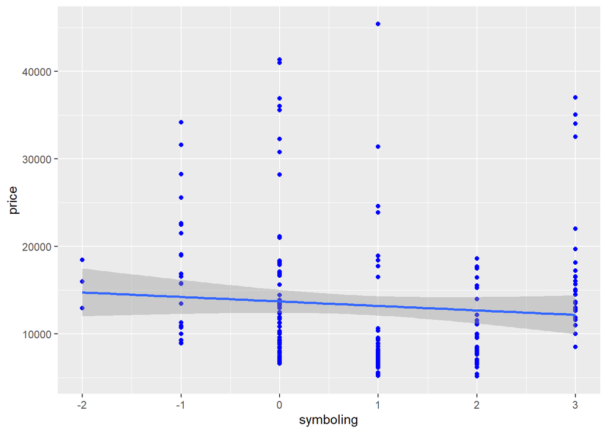

```r
library(ggplot2)

ggplot(carprice, aes(x = symboling, y = price)) +
  geom_point(color = "blue") +
  geom_smooth(method = "lm") +
  labs(x = "symboling", y = "price")
```

The scatterplot shows a weak negative linear relationship between symboling and price. The observations are widely scattered around the fitted line, indicating that symboling alone has a weak linear association with car price.

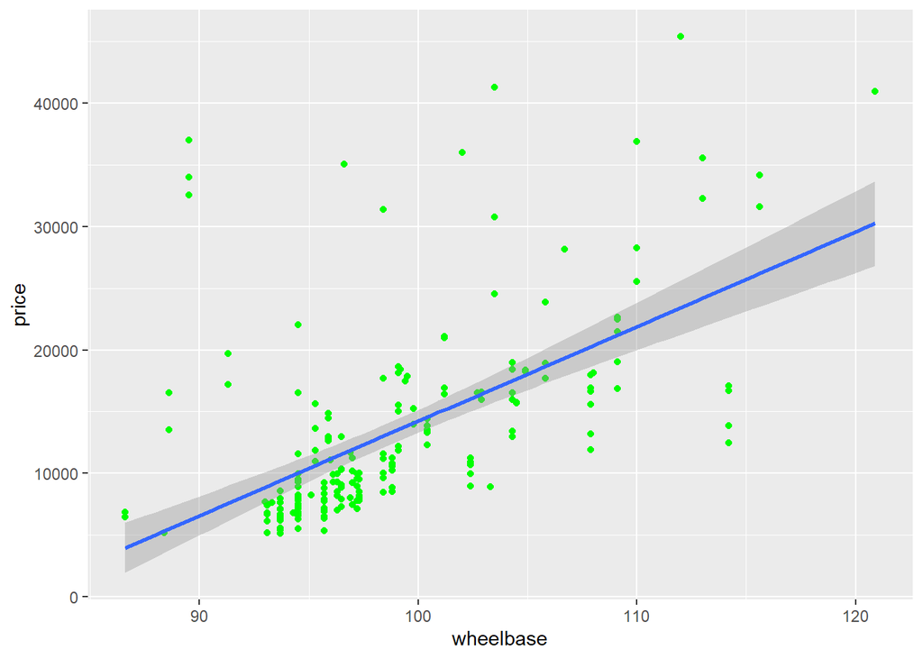

```r
ggplot(carprice, aes(x = wheelbase, y = price)) +
  geom_point(color = "green") +
  geom_smooth(method = "lm") +
  labs(x = "wheelbase", y = "price")
```

The scatterplot shows a moderate positive linear relationship between wheelbase and price. As wheelbase increases, car price generally tends to increase, although there is some variability around the fitted line.

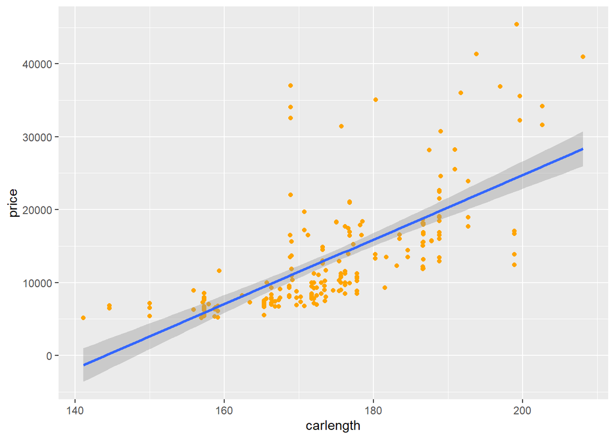

```r
ggplot(carprice, aes(x = carlength, y = price)) +
  geom_point(color = "orange") +
  geom_smooth(method = "lm") +
  labs(x = "carlength", y = "price")
```

The scatterplot shows a moderately strong positive linear relationship between carlength and price. As car length increases, car price generally increases, although some variability is present around the fitted line.

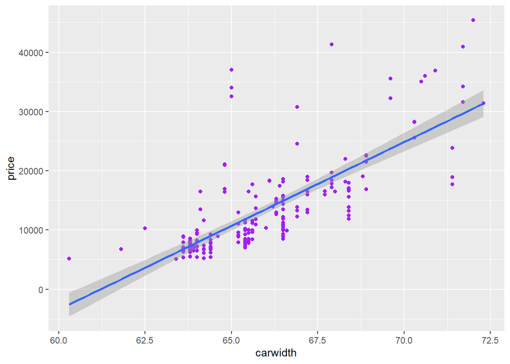

```r
ggplot(carprice, aes(x = carwidth, y = price)) +
  geom_point(color = "purple") +
  geom_smooth(method = "lm") +
  labs(x = "carwidth", y = "price")
```

The scatterplot shows a strong positive linear relationship between carwidth and price. As car width increases, car price generally increases, although some variability is present around the fitted line.

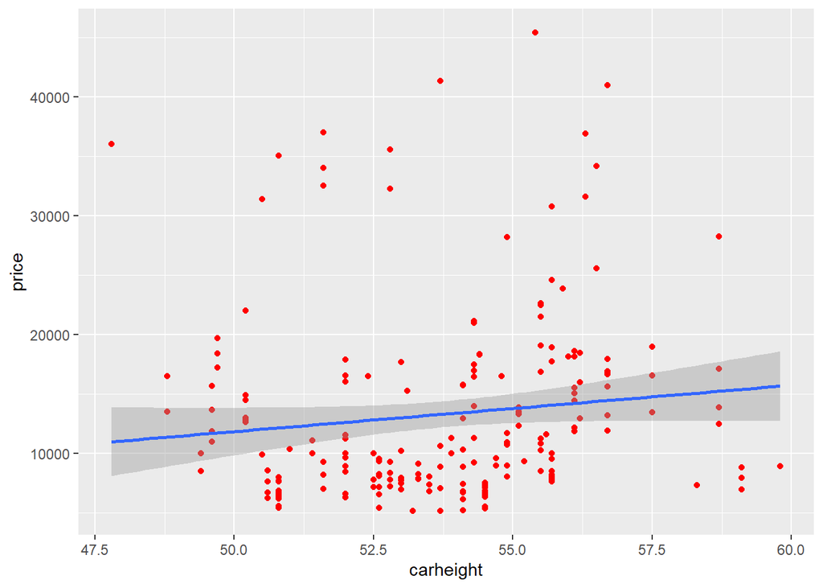

```r
ggplot(carprice, aes(x = carheight, y = price)) +
  geom_point(color = "red") +
  geom_smooth(method = "lm") +
  labs(x = "carheight", y = "price")
```

The scatterplot shows a weak positive linear relationship between carheight and price. The observations are widely scattered around the fitted line, indicating that carheight has only a weak linear association with car price.

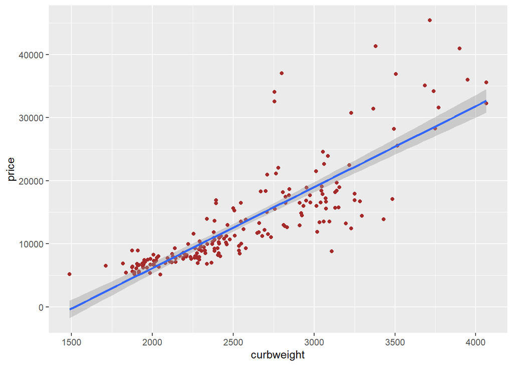

```r
ggplot(carprice, aes(x = curbweight, y = price)) +
  geom_point(color = "brown") +
  geom_smooth(method = "lm") +
  labs(x = "curbweight", y = "price")
```

The scatterplot shows a strong positive linear relationship between curbweight and price. As curb weight increases, car price generally increases, with most observations following the fitted linear trend.

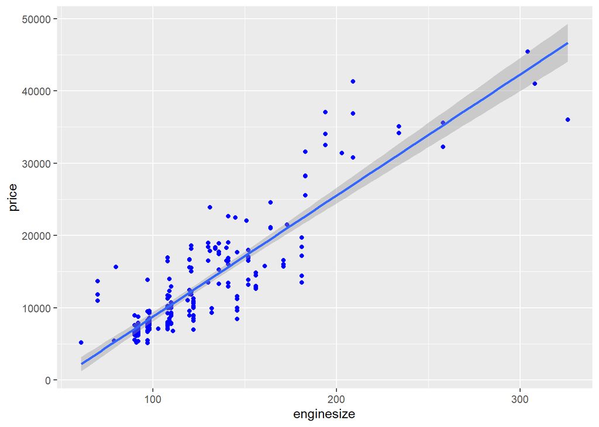

```r
ggplot(carprice, aes(x = enginesize, y = price)) +
  geom_point(color = "blue") +
  geom_smooth(method = "lm") +
  labs(x = "enginesize", y = "price")
```

The scatterplot shows a strong positive linear relationship between enginesize and price. As engine size increases, car price generally increases, with most observations following the fitted linear trend.

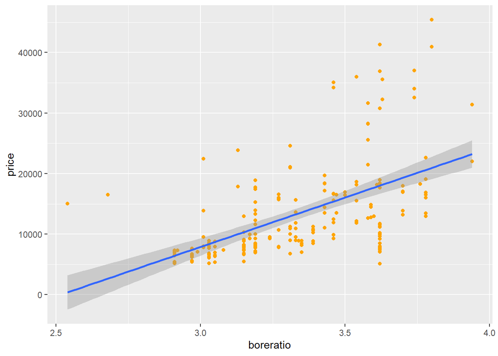

```r
ggplot(carprice, aes(x = boreratio, y = price)) +
  geom_point(color = "orange") +
  geom_smooth(method = "lm") +
  labs(x = "boreratio", y = "price")
```

The scatterplot shows a moderate positive linear relationship between boreratio and price. As bore ratio increases, car price generally tends to increase, although there is considerable variability around the fitted line.

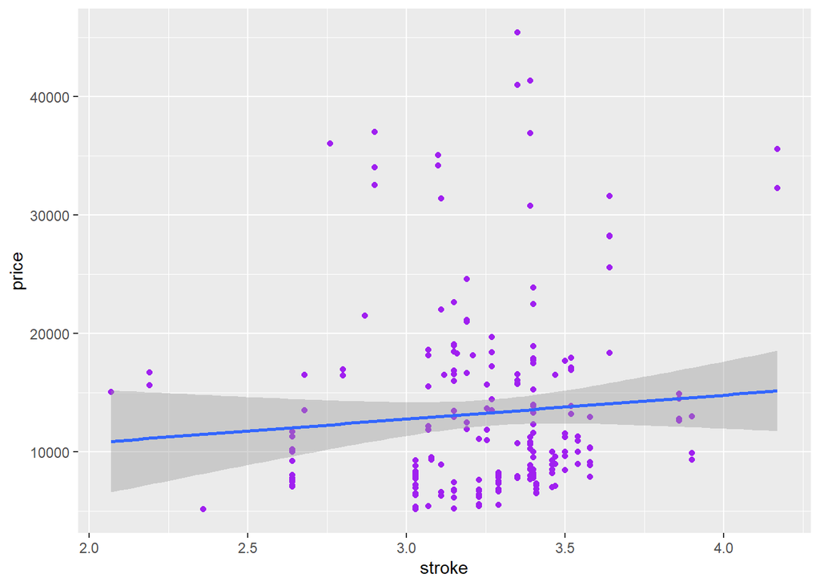

```r
ggplot(carprice, aes(x = stroke, y = price)) +
  geom_point(color = "purple") +
  geom_smooth(method = "lm") +
  labs(x = "stroke", y = "price")
```

The scatterplot shows a weak positive linear relationship between stroke and price. Although the regression line slopes slightly upward, the observations are widely scattered around the line, indicating that stroke alone is not a strong predictor of car price.

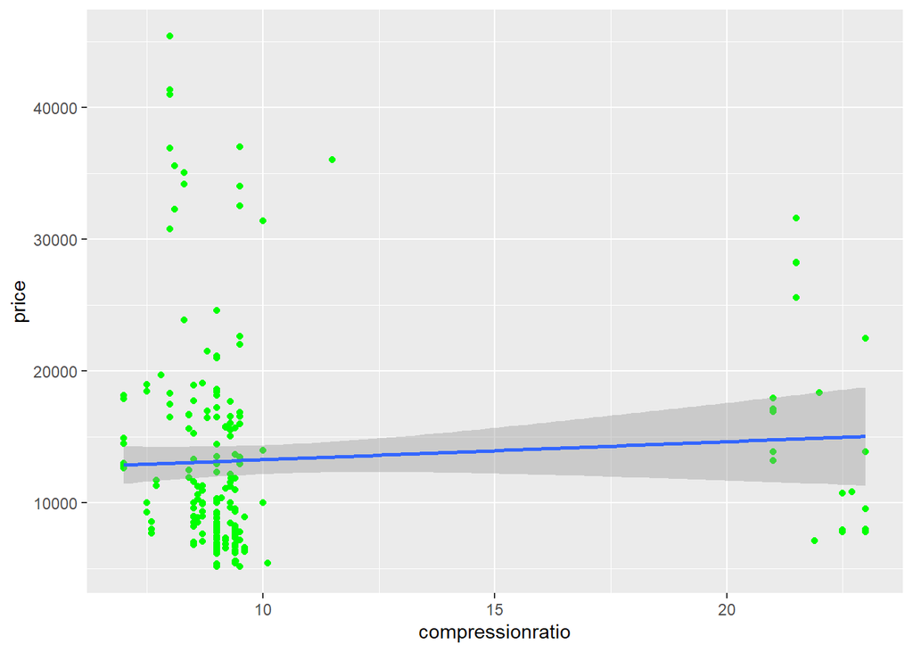

```r
ggplot(carprice, aes(x = compressionratio, y = price)) +
  geom_point(color = "green") +
  geom_smooth(method = "lm") +
  labs(x = "compressionratio", y = "price")
```

The scatterplot shows a weak positive linear relationship between compression ratio and price. The regression line has only a slight upward slope, while the observations are widely scattered, indicating that compression ratio alone is not a strong predictor of car price.

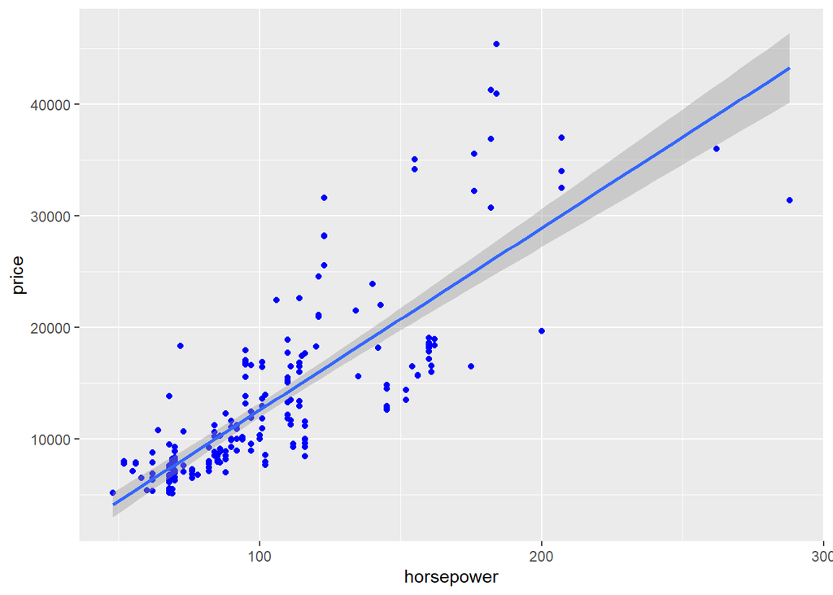

```r
ggplot(carprice, aes(x = horsepower, y = price)) +
  geom_point(color = "blue") +
  geom_smooth(method = "lm") +
  labs(x = "horsepower", y = "price")
```

The scatterplot shows a strong positive linear relationship between horsepower and price. As horsepower increases, the price of the car generally increases. Therefore, horsepower appears to be a strong predictor of car price.

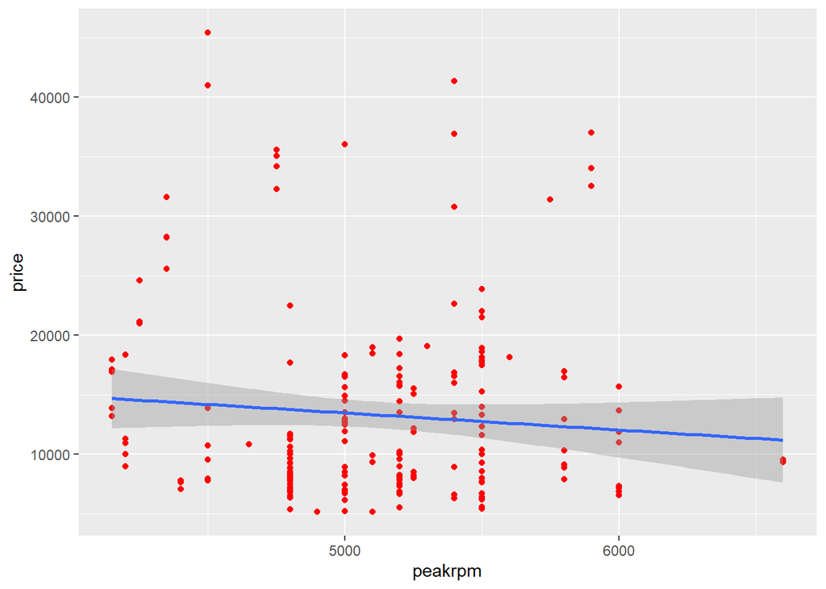

```r
ggplot(carprice, aes(x = peakrpm, y = price)) +
  geom_point(color = "red") +
  geom_smooth(method = "lm") +
  labs(x = "peakrpm", y = "price")
```

The scatterplot shows a weak negative linear relationship between peak RPM and price. The observations are widely scattered around the regression line, indicating that peak RPM alone is not a strong predictor of car price.

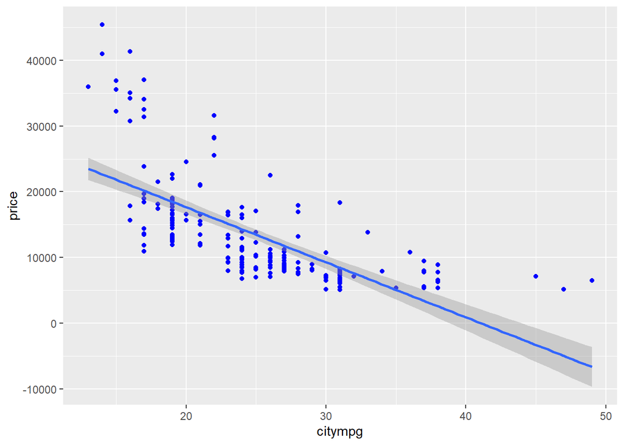

```r
ggplot(carprice, aes(x = citympg, y = price)) +
  geom_point(color = "blue") +
  geom_smooth(method = "lm") +
  labs(x = "citympg", y = "price")
```

The scatterplot shows a strong negative linear relationship between city MPG and price. As city MPG increases, car price generally decreases. Therefore, city MPG appears to be an important predictor of car price.

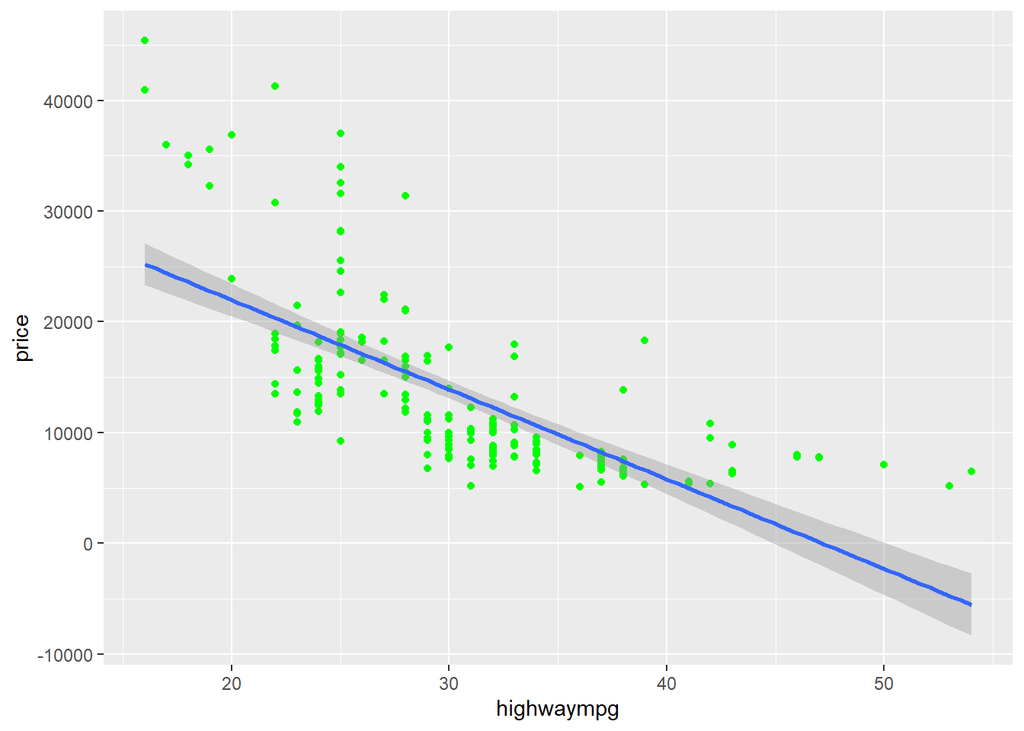

```r
ggplot(carprice, aes(x = highwaympg, y = price)) +
  geom_point(color = "green") +
  geom_smooth(method = "lm") +
  labs(x = "highwaympg", y = "price")
```

The scatterplot shows a strong negative linear relationship between highway MPG and price. As highway MPG increases, car price generally decreases. Therefore, highway MPG appears to be an important predictor of car price.

Overall, the numerical explanatory variables show different degrees of linear relationship with price. Car width, curb weight, engine size, and horsepower show strong positive relationships with price, while city MPG and highway MPG show strong negative relationships. Wheelbase, car length, and bore ratio show positive relationships of varying strength. In contrast, symboling, car height, stroke, compression ratio, and peak RPM show relatively weak linear relationships with price. Therefore, some numerical EVs appear to be considerably stronger predictors of car price than others.

## 6. Correlation Matrix

```r
numeric_data <- carprice[sapply(carprice, is.numeric)]

cor_matrix <- cor(numeric_data)

round(cor_matrix, 2)
```

```
##                  symboling wheelbase carlength carwidth carheight curbweight
## symboling             1.00     -0.53     -0.36    -0.23     -0.54      -0.23
## wheelbase            -0.53      1.00      0.87     0.80      0.59       0.78
## carlength            -0.36      0.87      1.00     0.84      0.49       0.88
## carwidth             -0.23      0.80      0.84     1.00      0.28       0.87
## carheight            -0.54      0.59      0.49     0.28      1.00       0.30
## curbweight           -0.23      0.78      0.88     0.87      0.30       1.00
## enginesize           -0.11      0.57      0.68     0.74      0.07       0.85
## boreratio            -0.13      0.49      0.61     0.56      0.17       0.65
## stroke               -0.01      0.16      0.13     0.18     -0.06       0.17
## compressionratio     -0.18      0.25      0.16     0.18      0.26       0.15
## horsepower            0.07      0.35      0.55     0.64     -0.11       0.75
## peakrpm               0.27     -0.36     -0.29    -0.22     -0.32      -0.27
## citympg              -0.04     -0.47     -0.67    -0.64     -0.05      -0.76
## highwaympg            0.03     -0.54     -0.70    -0.68     -0.11      -0.80
## price                -0.08      0.58      0.68     0.76      0.12       0.84
##                  enginesize boreratio stroke compressionratio horsepower
## symboling             -0.11     -0.13  -0.01            -0.18       0.07
## wheelbase              0.57      0.49   0.16             0.25       0.35
## carlength              0.68      0.61   0.13             0.16       0.55
## carwidth               0.74      0.56   0.18             0.18       0.64
## carheight              0.07      0.17  -0.06             0.26      -0.11
## curbweight             0.85      0.65   0.17             0.15       0.75
## enginesize             1.00      0.58   0.20             0.03       0.81
## boreratio              0.58      1.00  -0.06             0.01       0.57
## stroke                 0.20     -0.06   1.00             0.19       0.08
## compressionratio       0.03      0.01   0.19             1.00      -0.20
## horsepower             0.81      0.57   0.08            -0.20       1.00
## peakrpm               -0.24     -0.25  -0.07            -0.44       0.13
## citympg               -0.65     -0.58  -0.04             0.32      -0.80
## highwaympg            -0.68     -0.59  -0.04             0.27      -0.77
## price                  0.87      0.55   0.08             0.07       0.81
##                  peakrpm citympg highwaympg price
## symboling           0.27   -0.04       0.03 -0.08
## wheelbase          -0.36   -0.47      -0.54  0.58
## carlength          -0.29   -0.67      -0.70  0.68
## carwidth           -0.22   -0.64      -0.68  0.76
## carheight          -0.32   -0.05      -0.11  0.12
## curbweight         -0.27   -0.76      -0.80  0.84
## enginesize         -0.24   -0.65      -0.68  0.87
## boreratio          -0.25   -0.58      -0.59  0.55
## stroke             -0.07   -0.04      -0.04  0.08
## compressionratio   -0.44    0.32       0.27  0.07
## horsepower          0.13   -0.80      -0.77  0.81
## peakrpm             1.00   -0.11      -0.05 -0.09
## citympg            -0.11    1.00       0.97 -0.69
## highwaympg         -0.05    0.97       1.00 -0.70
## price              -0.09   -0.69      -0.70  1.00
```

The correlation matrix shows that engine size (r = 0.87), curb weight (r = 0.84), horsepower (r = 0.81), and car width (r = 0.76) have strong positive correlations with price. City MPG (r = -0.69) and highway MPG (r = -0.70) have relatively strong negative correlations with price. In contrast, symboling, stroke, compression ratio, peak RPM, and car height have weak correlations with price. The matrix also shows strong correlations among some explanatory variables, such as city MPG and highway MPG (r = 0.97), which may indicate multicollinearity.

## 7. Final Linear Regression Model

```r
model1 <- lm(price ~ . - CarName, data = carprice)

summary(model1)
```

```
##
## Call:
## lm(formula = price ~ . - CarName, data = carprice)
##
## Residuals:
##     Min      1Q  Median      3Q     Max
## -5416.2 -1152.0   -35.8   830.8  9835.6
##
## Coefficients: (2 not defined because of singularities)
##                        Estimate Std. Error t value Pr(>|t|)
## (Intercept)          -2.226e+04  1.652e+04  -1.347 0.179705
## symboling             7.388e+01  2.386e+02   0.310 0.757238
## fueltypegas          -1.178e+04  7.017e+03  -1.678 0.095232 .
## aspirationturbo       1.626e+03  8.856e+02   1.836 0.068172 .
## doornumbertwo         1.876e+02  5.854e+02   0.320 0.749028
## carbodyhardtop       -3.207e+03  1.376e+03  -2.331 0.020992 *
## carbodyhatchback     -3.281e+03  1.223e+03  -2.683 0.008055 **
## carbodysedan         -2.152e+03  1.332e+03  -1.615 0.108182
## carbodywagon         -3.266e+03  1.455e+03  -2.244 0.026191 *
## drivewheelfwd         7.405e+01  1.040e+03   0.071 0.943351
## drivewheelrwd         1.033e+03  1.205e+03   0.857 0.392688
## enginelocationrear    7.695e+03  2.536e+03   3.035 0.002802 **
## wheelbase             4.882e+01  9.675e+01   0.505 0.614563
## carlength            -6.130e+01  4.875e+01  -1.257 0.210410
## carwidth              6.936e+02  2.394e+02   2.897 0.004283 **
## carheight             8.943e+01  1.278e+02   0.700 0.485209
## curbweight            3.942e+00  1.715e+00   2.299 0.022781 *
## enginetypedohcv      -7.189e+03  4.674e+03  -1.538 0.125912
## enginetypel          -1.051e+03  1.608e+03  -0.654 0.514246
## enginetypeohc         3.126e+03  9.088e+02   3.439 0.000741 ***
## enginetypeohcf        1.234e+03  1.572e+03   0.785 0.433661
## enginetypeohcv       -5.605e+03  1.247e+03  -4.495 1.31e-05 ***
## enginetyperotor      -6.925e+01  4.505e+03  -0.015 0.987754
## cylindernumberfive   -9.280e+03  2.716e+03  -3.417 0.000800 ***
## cylindernumberfour   -9.879e+03  3.054e+03  -3.234 0.001476 **
## cylindernumbersix    -6.570e+03  2.192e+03  -2.997 0.003154 **
## cylindernumberthree  -4.629e+02  4.499e+03  -0.103 0.918173
## cylindernumbertwelve -1.024e+04  4.384e+03  -2.336 0.020707 *
## cylindernumbertwo            NA         NA      NA       NA
## enginesize            1.174e+02  2.600e+01   4.515 1.21e-05 ***
## fuelsystem2bbl       -3.907e+01  8.920e+02  -0.044 0.965118
## fuelsystem4bbl       -1.624e+03  2.775e+03  -0.585 0.559295
## fuelsystemidi                NA         NA      NA       NA
## fuelsystemmfi        -3.480e+03  2.590e+03  -1.344 0.180967
## fuelsystemmpfi       -2.444e+02  1.001e+03  -0.244 0.807415
## fuelsystemspdi       -3.027e+03  1.382e+03  -2.191 0.029883 *
## fuelsystemspfi       -6.187e+02  2.508e+03  -0.247 0.805484
## boreratio            -1.882e+03  1.598e+03  -1.178 0.240443
## stroke               -4.454e+03  9.009e+02  -4.944 1.89e-06 ***
## compressionratio     -8.003e+02  5.259e+02  -1.522 0.129981
## horsepower            9.791e+00  2.227e+01   0.440 0.660789
## peakrpm               2.202e+00  6.194e-01   3.555 0.000495 ***
## citympg              -1.477e+02  1.474e+02  -1.003 0.317569
## highwaympg            1.916e+02  1.347e+02   1.422 0.156916
## ---
## Signif. codes:  0 '***' 0.001 '**' 0.01 '*' 0.05 '.' 0.1 ' ' 1
##
## Residual standard error: 2197 on 163 degrees of freedom
## Multiple R-squared:  0.9395, Adjusted R-squared:  0.9243
## F-statistic: 61.79 on 41 and 163 DF,  p-value: < 2.2e-16
```

```r
model_final <- step(model1, direction = "backward")
```

```
## Start:  AIC=3191.97
## price ~ (symboling + CarName + fueltype + aspiration + doornumber +
##     carbody + drivewheel + enginelocation + wheelbase + carlength +
##     carwidth + carheight + curbweight + enginetype + cylindernumber +
##     enginesize + fuelsystem + boreratio + stroke + compressionratio +
##     horsepower + peakrpm + citympg + highwaympg) - CarName
##
##
## Step:  AIC=3191.97
## price ~ symboling + aspiration + doornumber + carbody + drivewheel +
##     enginelocation + wheelbase + carlength + carwidth + carheight +
##     curbweight + enginetype + cylindernumber + enginesize + fuelsystem +
##     boreratio + stroke + compressionratio + horsepower + peakrpm +
##     citympg + highwaympg
##
##                    Df Sum of Sq        RSS    AIC
## - fuelsystem        7  40218055  827305337 3188.2
## - symboling         1    462935  787550216 3190.1
## - doornumber        1    495895  787583177 3190.1
## - horsepower        1    933268  788020550 3190.2
## - wheelbase         1   1229211  788316493 3190.3
## - drivewheel        2   9029467  796116749 3190.3
## - carheight         1   2363013  789450295 3190.6
## - citympg           1   4853313  791940595 3191.2
## - boreratio         1   6702797  793790079 3191.7
## - carlength         1   7634435  794721717 3192.0
## <none>                           787087282 3192.0
## - highwaympg        1   9765142  796852423 3192.5
## - compressionratio  1  11183738  798271020 3192.9
## - aspiration        1  16278085  803365367 3194.2
## - curbweight        1  25519318  812606600 3196.5
## - carwidth          1  40530808  827618090 3200.3
## - enginelocation    1  44475201  831562482 3201.2
## - carbody           4  74980685  862067967 3202.6
## - peakrpm           1  61029992  848117274 3205.3
## - enginesize        1  98428535  885515817 3214.1
## - stroke            1 118006529  905093810 3218.6
## - cylindernumber    5 193799940  980887221 3227.1
## - enginetype        5 365581564 1152668846 3260.2
##
```

[output cut: 196 more lines]

```
## <none>                         848726638 3179.4
## - boreratio       1   8650968  857377605 3179.5
## - carheight       1  11411159  860137797 3180.2
## - drivewheel      2  21210740  869937378 3180.5
## - highwaympg      1  20794032  869520669 3182.4
## - curbweight      1  21950397  870677035 3182.7
## - carwidth        1  45572762  894299400 3188.2
## - enginelocation  1  65506546  914233183 3192.7
## - carbody         4 100813019  949539657 3194.4
## - aspiration      1  86024116  934750754 3197.2
## - peakrpm         1 109940853  958667490 3202.4
## - stroke          1 135062480  983789117 3207.7
## - enginesize      1 178641492 1027368130 3216.6
## - cylindernumber  5 235767659 1084494297 3219.7
## - enginetype      5 346799385 1195526022 3239.7
```

```r
summary(model_final)
```

```
##
## Call:
## lm(formula = price ~ aspiration + carbody + drivewheel + enginelocation +
##     carwidth + carheight + curbweight + enginetype + cylindernumber +
##     enginesize + boreratio + stroke + peakrpm + highwaympg, data = carprice)
##
## Residuals:
##     Min      1Q  Median      3Q     Max
## -5965.0 -1024.6   -70.9  1026.0 10446.1
##
## Coefficients: (1 not defined because of singularities)
##                        Estimate Std. Error t value Pr(>|t|)
## (Intercept)          -4.554e+04  1.299e+04  -3.504 0.000580 ***
## aspirationturbo       2.227e+03  5.257e+02   4.236 3.66e-05 ***
## carbodyhardtop       -3.853e+03  1.277e+03  -3.018 0.002920 **
## carbodyhatchback     -3.695e+03  1.093e+03  -3.383 0.000884 ***
## carbodysedan         -2.908e+03  1.115e+03  -2.608 0.009897 **
## carbodywagon         -4.271e+03  1.246e+03  -3.427 0.000760 ***
## drivewheelfwd        -4.902e+02  9.710e+02  -0.505 0.614345
## drivewheelrwd         7.827e+02  1.076e+03   0.727 0.467985
## enginelocationrear    7.646e+03  2.069e+03   3.696 0.000292 ***
## carwidth              6.122e+02  1.986e+02   3.083 0.002379 **
## carheight             1.598e+02  1.036e+02   1.543 0.124702
## curbweight            3.127e+00  1.462e+00   2.140 0.033761 *
## enginetypedohcv      -4.574e+03  3.340e+03  -1.369 0.172586
## enginetypel           6.602e+01  1.188e+03   0.056 0.955726
## enginetypeohc         3.193e+03  8.167e+02   3.910 0.000131 ***
## enginetypeohcf        1.534e+03  1.405e+03   1.092 0.276391
## enginetypeohcv       -5.158e+03  1.124e+03  -4.589 8.40e-06 ***
## enginetyperotor       1.049e+03  3.929e+03   0.267 0.789731
## cylindernumberfive   -7.569e+03  2.618e+03  -2.892 0.004314 **
## cylindernumberfour   -9.189e+03  2.975e+03  -3.088 0.002337 **
## cylindernumbersix    -5.744e+03  2.031e+03  -2.829 0.005216 **
## cylindernumberthree  -1.399e+03  4.324e+03  -0.324 0.746617
## cylindernumbertwelve -1.191e+04  2.988e+03  -3.987 9.79e-05 ***
## cylindernumbertwo            NA         NA      NA       NA
## enginesize            1.339e+02  2.193e+01   6.104 6.38e-09 ***
## boreratio            -2.018e+03  1.503e+03  -1.343 0.180933
## stroke               -4.387e+03  8.266e+02  -5.307 3.30e-07 ***
## peakrpm               2.268e+00  4.737e-01   4.788 3.54e-06 ***
## highwaympg            1.050e+02  5.043e+01   2.082 0.038740 *
## ---
## Signif. codes:  0 '***' 0.001 '**' 0.01 '*' 0.05 '.' 0.1 ' ' 1
##
## Residual standard error: 2190 on 177 degrees of freedom
## Multiple R-squared:  0.9348, Adjusted R-squared:  0.9249
## F-statistic: 94.01 on 27 and 177 DF,  p-value: < 2.2e-16
```

```r
alias(model_final)
```

```
## Model :
## price ~ aspiration + carbody + drivewheel + enginelocation +
##     carwidth + carheight + curbweight + enginetype + cylindernumber +
##     enginesize + boreratio + stroke + peakrpm + highwaympg
##
## Complete :
##                   (Intercept) aspirationturbo carbodyhardtop carbodyhatchback
## cylindernumbertwo 0           0               0              0
##                   carbodysedan carbodywagon drivewheelfwd drivewheelrwd
## cylindernumbertwo 0            0            0             0
##                   enginelocationrear carwidth carheight curbweight
## cylindernumbertwo 0                  0        0         0
##                   enginetypedohcv enginetypel enginetypeohc enginetypeohcf
## cylindernumbertwo 0               0           0             0
##                   enginetypeohcv enginetyperotor cylindernumberfive
## cylindernumbertwo 0              1               0
##                   cylindernumberfour cylindernumbersix cylindernumberthree
## cylindernumbertwo 0                  0                 0
##                   cylindernumbertwelve enginesize boreratio stroke peakrpm
## cylindernumbertwo 0                    0          0         0      0
##                   highwaympg
## cylindernumbertwo 0
```

```r
library(car)
model_vif <- update(model_final, . ~ . - enginetype)

vif(model_vif)
```

```
##                     GVIF Df GVIF^(1/(2*Df))
## aspiration      1.712477  1        1.308616
## carbody         3.960874  4        1.187747
## drivewheel      4.005877  2        1.414733
## enginelocation  1.861245  1        1.364275
## carwidth        7.444162  1        2.728399
## carheight       2.477942  1        1.574148
## curbweight     21.146643  1        4.598548
## cylindernumber 49.905982  6        1.385201
## enginesize     27.786401  1        5.271281
## boreratio       4.254078  1        2.062542
## stroke          2.091426  1        1.446177
## peakrpm         1.855780  1        1.362270
## highwaympg      4.851737  1        2.202666
```

```r
model_vif2 <- update(model_vif, . ~ . - enginesize)

vif(model_vif2)
```

```
##                     GVIF Df GVIF^(1/(2*Df))
## aspiration      1.569950  1        1.252976
## carbody         3.560020  4        1.172011
## drivewheel      3.790971  2        1.395364
## enginelocation  1.812943  1        1.346456
## carwidth        7.312777  1        2.704215
## carheight       2.440872  1        1.562329
## curbweight     15.513663  1        3.938739
## cylindernumber 12.266299  6        1.232327
## boreratio       3.066222  1        1.751063
## stroke          1.496382  1        1.223267
## peakrpm         1.760661  1        1.326899
## highwaympg      4.735174  1        2.176046
```

```r
model_vif3 <- update(model_vif2, . ~ . - curbweight)

vif(model_vif3)
```

```
##                    GVIF Df GVIF^(1/(2*Df))
## aspiration     1.471283  1        1.212965
## carbody        3.225876  4        1.157660
## drivewheel     3.006585  2        1.316796
## enginelocation 1.810954  1        1.345717
## carwidth       4.873269  1        2.207548
## carheight      2.331896  1        1.527055
## cylindernumber 8.757413  6        1.198206
## boreratio      2.974812  1        1.724764
## stroke         1.333856  1        1.154927
## peakrpm        1.671270  1        1.292776
## highwaympg     3.845562  1        1.961010
```

```r
model_final <- model_vif3

summary(model_final)
```

```
##
## Call:
## lm(formula = price ~ aspiration + carbody + drivewheel + enginelocation +
##     carwidth + carheight + cylindernumber + boreratio + stroke +
##     peakrpm + highwaympg, data = carprice)
##
## Residuals:
##     Min      1Q  Median      3Q     Max
## -6396.9 -1446.7  -175.5  1177.5 16896.2
##
## Coefficients:
##                        Estimate Std. Error t value Pr(>|t|)
## (Intercept)          -6.728e+04  1.538e+04  -4.376 2.02e-05 ***
## aspirationturbo       1.571e+03  6.517e+02   2.411  0.01690 *
## carbodyhardtop       -3.458e+03  1.649e+03  -2.097  0.03737 *
## carbodyhatchback     -4.364e+03  1.414e+03  -3.086  0.00234 **
## carbodysedan         -3.383e+03  1.444e+03  -2.342  0.02024 *
## carbodywagon         -5.321e+03  1.612e+03  -3.300  0.00116 **
## drivewheelfwd        -2.930e+02  1.192e+03  -0.246  0.80616
## drivewheelrwd         2.308e+03  1.230e+03   1.876  0.06226 .
## enginelocationrear    1.263e+04  2.316e+03   5.452 1.58e-07 ***
## carwidth              1.040e+03  2.132e+02   4.879 2.30e-06 ***
## carheight             2.648e+02  1.294e+02   2.046  0.04219 *
## cylindernumberfive   -1.126e+04  1.760e+03  -6.397 1.27e-09 ***
## cylindernumberfour   -1.595e+04  1.831e+03  -8.712 1.70e-15 ***
## cylindernumbersix    -8.754e+03  1.734e+03  -5.048 1.07e-06 ***
## cylindernumberthree  -1.139e+04  3.945e+03  -2.887  0.00435 **
## cylindernumbertwelve  2.424e+03  3.447e+03   0.703  0.48275
## cylindernumbertwo    -1.519e+04  2.347e+03  -6.471 8.58e-10 ***
## boreratio             2.920e+03  1.319e+03   2.214  0.02807 *
## stroke                1.078e+03  7.629e+02   1.413  0.15929
## peakrpm               7.627e-01  5.614e-01   1.359  0.17595
## highwaympg           -7.497e+01  5.899e+01  -1.271  0.20533
## ---
## Signif. codes:  0 '***' 0.001 '**' 0.01 '*' 0.05 '.' 0.1 ' ' 1
##
## Residual standard error: 2959 on 184 degrees of freedom
## Multiple R-squared:  0.8763, Adjusted R-squared:  0.8629
## F-statistic: 65.17 on 20 and 184 DF,  p-value: < 2.2e-16
```

## 8a. Statistical test - Shapiro-Wilk normality test

```r
shapiro.test(residuals(model_final))
```

```
##
##  Shapiro-Wilk normality test
##
## data:  residuals(model_final)
## W = 0.9122, p-value = 1.144e-09
```

The Shapiro-Wilk test produced a p-value of 1.144e-09, which is less than 0.05. Therefore, the null hypothesis of normality is rejected, indicating that the residuals of the final model are not normally distributed.

#8b. Graphical representation - Normal Q-Q Plot

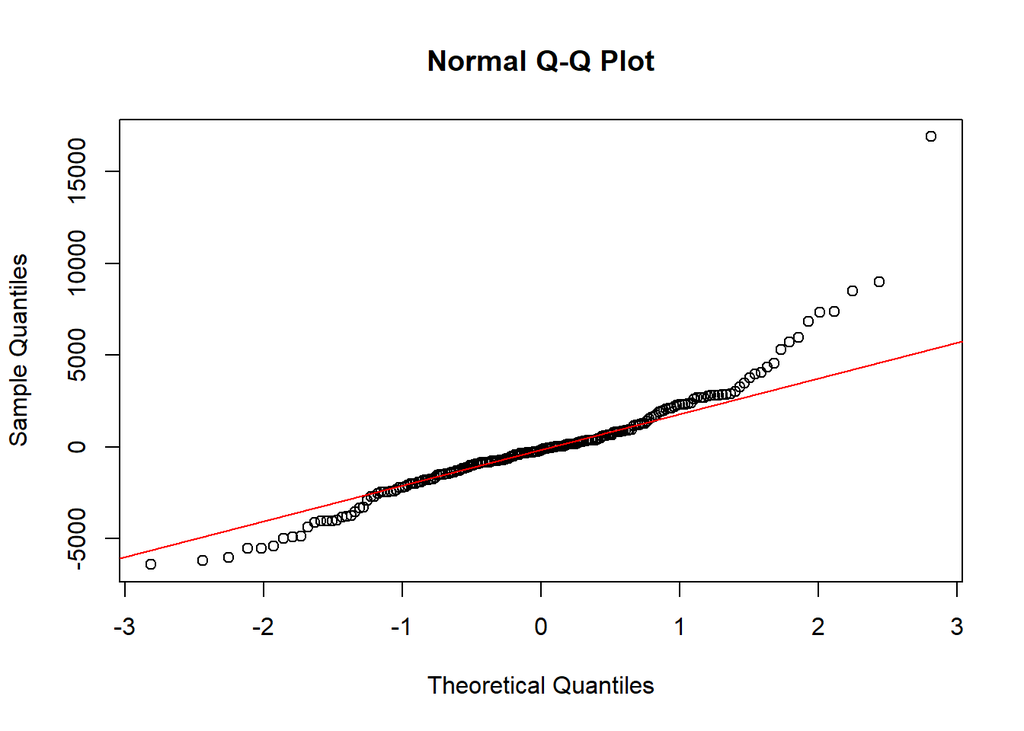

```r
qqnorm(residuals(model_final))
qqline(residuals(model_final), col = "red")
```

The Q-Q plot shows noticeable deviations from the reference line, particularly in the tails. This supports the Shapiro-Wilk test result and indicates that the residuals are not normally distributed.

```r
library(lmtest)
bptest(model_final)
```

```
##
##  studentized Breusch-Pagan test
##
## data:  model_final
## BP = 55.618, df = 20, p-value = 3.318e-05
```

The Breusch-Pagan test produced a p-value of 3.318e-05, which is less than 0.05. Therefore, the null hypothesis of constant variance is rejected. This indicates that heteroscedasticity is present in the final regression model, meaning that the variance of the residuals is not constant.

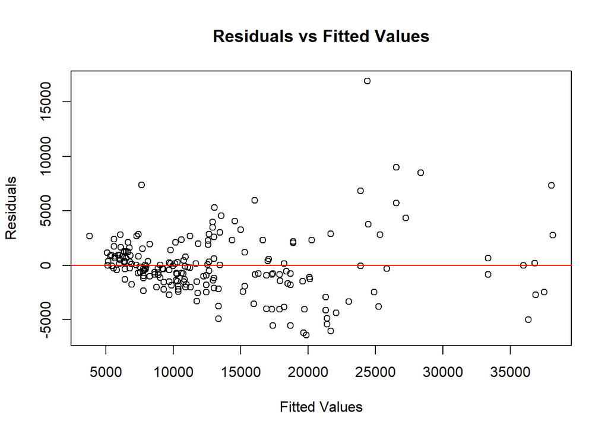

```r
plot(model_final$fitted.values,
     residuals(model_final),
     xlab = "Fitted Values",
     ylab = "Residuals",
     main = "Residuals vs Fitted Values")

abline(h = 0, col = "red")
```

The Residuals vs. Fitted Values plot shows that the spread of the residuals is not constant across the range of fitted values, with greater variability occurring at some higher fitted values. This supports the Breusch-Pagan test result (p = 3.318e-05). Therefore, the evidence suggests heteroscedasticity, indicating that the constant variance assumption is violated.